# Einführung in Reinforcement Learning:

Reinforcement-Learning ist eines der interessantesten Felder im Bereich der Künstlichen Intelligenz. In vielen Bereichen zeichnet es sich ab, dass das alleinige Sammeln von Daten nicht ausreichend ist appropriate Ergebnisse und Werte zu erzielen. Das Reinforcement-Learning geht einen anderen Ansatz. Anstatt nur aus Grundlage vieler Daten Muster und Regeln abzuleiten, erschließen sich diese Muster und Regeln durch eine Art Try and Error Prinzip. Seid den Untersuchungen von Iwan Pawlow kennen wir das Prinzip der Konditionierung. Das "richtige" Verhalten wird belohnt das "falsche" bestraft. Doch wie können wir den Bogen zum Reinforcement-Learning im Musikbereich spannen? Daher voher eine kurze Einführung.

Das Reinforcement-Learning besteht aus 4 Bestandteilen:

**1. Das Environment**

Das Environement ist sozusagen die Spielwiese des Modells. Es ist der Rahmen in dem unser "Protagonist" bzw. Agent Aktionen(dazu gleich mehr) ausführt. Z.B. kann man sich darunter das Level eines Compuerspiels vorstellen. Wie unten zu sehen eine ganz einfache Darstellung eines Environments im übetragenen Sinne.

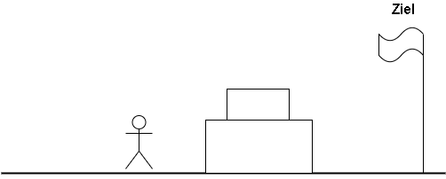

**2. Agent**

Der Agent ist die Spielfigur, die sich im Environemt bewegt und Aktionen ausführt. Bei Mario Kart wäre das z.B. einfach Mario ("wer nimmt Luigi??").

**3. Action**

Der Agent führt Aktionen (Actions) aus. Bei einem einfachen Plattformspiel kann man sich darunter z.B. einfach vorstellen, dass der Agent entweder vorwärts bzw. rückwärts läuft, springt oder aber stehenbleibt. Bei Mario Kart würden hier weitere Aktionen definiert werden...

**4. Rewards**

Wie oben bereits erwähnt wollen wir nach Pawlow-Manier das Verhalten bzw. die Aktionen des Agents entweder loben oder tadeln. Dies ist mit Rewards möglich. Für eine richtig ausgeführte Aktion im Environment erhält der Agent eine Belohnung (positiven Wert), bei einer falschen Aktion eine Strafe (negativen Wert). Der Agent versucht dabei stets die maximale Anzahl an Rewards zu erhalten bevor er z.B. das Spiel terminiert und merkt sich den Verlauf der Aktionen bei denen er eine Strafe erhalten hat. So weiß er es beim nächsten Versuch besser und begeht den selben Fehler nicht nocheinmal.

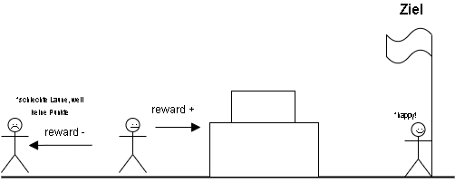

Das hier war nur eine ganz kurze Einführung in das Reinforcement Learning. Hier noch ein paar gute Quellen zum Thema, falls das jmd. vertiefen möchte:

https://datasolut.com/reinforcement-learning/

https://www.sigs-datacom.de/trendletter/2018-06/4-ein-kompakter-ueberblick-zu-reinforcement-learning/

# Reinforcement Learning in der Musik

Diese Grundlagen des RL können in Bezug zur Musik wunderbar eingesetzt werden. Schon länger werden Texte und Musik durch Deep-Learning generiert, dabei verwendet man meistens Rekurennte Neuronale Netze und LSTM-Layers. Die Ergebnisse, vor allem bei größeren Projekten sind sehr gut, aber die Resultate wirken auch, da sie immer auf alten Daten aufbauen, wie eine Wiederholung von Ideen die schon durchdacht wurden. RL wäre hier ein alternativer Ansatz, der sehr vielversprechend ist.

Das Ziel des hier dargestellten Models ist es, die Tonhöhen einer Midi-Datei zu extrahieren, die einzelnen Noten zu identifizieren, mit diesen Vorgaben ein Training mit den Tonhöhen durchzuführen und dann anschließend das verwendete Musikstück korrekt widergeben zu können.

**1. Environment**

Unten sehen wir verschiedene Tonhöhen, die in einer Midi-Datei codiert sind. Insgesamt gibt es 128 verschiede Tonhöhen. Das Environment können wir uns als ein Keyboard mit 128 verschiedenen Tasten vorstellen, jede Taste besitzt einen Wert zwischen 0 und 127.

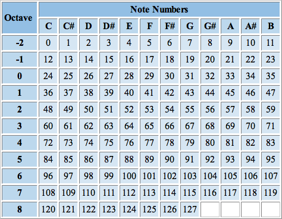

**2. Agent**

Unser Agent ist jetzt der Klavierspieler, der jede Taste drücken und durch jede Tonhöhe springen kann.

**3. Actions**

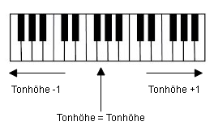

**4. Reward**

Nähert sich der Agent der gesuchten Note, so erhält dieser einen höheren Reward. Entfernt sich der Agent, so verringert sich der Reward. Im Anschluss wird der Output des Modells mit dem Imput verglichen. Stimmen beide überein so erhält das Modell wiederum einen zusätzlichen Reward.

**Hier noch einmal eine Veranschaulichung des Vorgangs:**

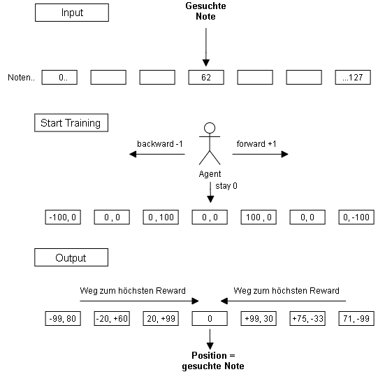

# Ablauf des Algorithmus

Der obere Abschnitt war noch recht abstrakt. Wie genau der Output des Algorithmus aussieht folgt hier.

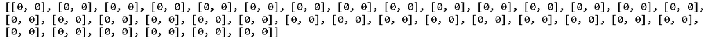

**Anschließend werden diese 32 Array-Objekten als Environment verwendet. Nach dem Training sieht das Array folgendermaßen aus:** **Hier wurde z.B. die Note 45 gesucht und diese ist im Zweiten Abschnitt aller Tonhöhen.**

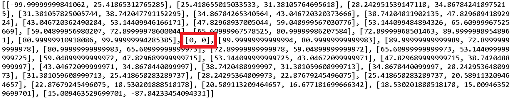

**Jetzt wird der einzelne Teil wieder zu den restlichen 96 Tonhöhen hinzugefügt, was dann so aussieht:**

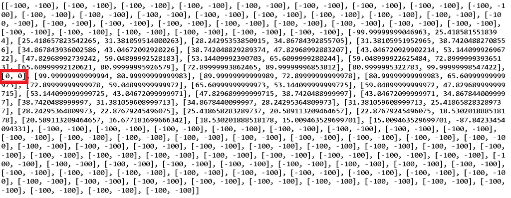

**Nachdem die Note gefunden wurde springt das Modell zur nächsten Note innerhalb der List und beginnt das Training mit dieser Note. Wenn alle Noten eines Stücks innerhalb des Trainingsvorgangs waren terminiert das Modell** **Im letzten Schritt wird überprüft, ob der Output auch mit dem Input übereinstimmt:**

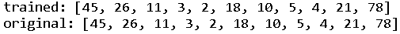

# Vorab wie es in Zukunft weitegeht...

Bevor wir uns dem eigentlichen Code widmen sei hier gesagt, dass dies noch lange nicht die fertige Version ist! Der 1. Schritt wird sein mehr Funktionen und OOP (auch wenn ich OOP hasse!) zu integrieren. Der weitere Schritt ist ein Neuronales Netz zu implementieren, welches für das Training eingesetzt wird und das Training noch eine Dimension höher zu bringen, wobei auch Kombinationen von Tönen und auch Tonlänge, sowie Rhythmus berücksichtigt werden.

# Der Algorithmus

Zu Beginn müssen wir erst einmal die benötigten Packages von Python laden...

```python
import random
import glob
import numpy as np
import pathlib
!pip install pretty_midi
import pretty_midi
import os
```

Anschließend importieren wir das Midi-File...

```python
data_dir = pathlib.PureWindowsPath('filepath') #hier wird der Pfad zum Midi-File eingegeben.

filenames = glob.glob(str(data_dir/'**/*.mid*')) #und filtern, dass wir nur midi-datein erhalten.
sample_file = filenames[0] # 1.Stück aus der Anzahl aller midi-files
pm = pretty_midi.PrettyMIDI(sample_file)
instrument = pm.instruments[0] # Noten des 1. auftretendes Instruments im Stück
instrument_name = pretty_midi.program_to_instrument_name(instrument.program)

notelist = []

for i, note in enumerate(instrument.notes[:(len(instrument.notes)-1)]):

  note_name = pretty_midi.note_number_to_name(note.pitch)
  note = int(note.pitch)
  notelist.append(note)

 #Als Ergebnis erhalten wir eine Liste welches aus allen Midi-Noten(Erklärung siehe Text) des ausgewählten Stücks besteht.
 #Ein Array wäre zwar wesentlich effizienter, aber besitzt ein Array nicht ausreichend manipulationsmöglichkeiten, um hier verwendung zu finden
```

```python
print(notelist) #Alle Noten, die im Stück auftreten.
```

[output not shown]

Nun folgt der eigentliche Algorithmus...

```python
if 0 in notelist or 127 in notelist: #die beiden extremwerte 0 und 127 führen zu extremen verzerrungen, werden deshalb vorab entfernt
    notelist.remove(0)
    notelist.remove(127)

if min(notelist) >= 0 and max(notelist) <= 127: #hier überprüfen wir, dass die Noten in der Notenliste dem richtigen Format (0-127) entsprechen.

 listindex = 0 #wir beginnen beim Index 0 in der Notenliste, also der 1. Note.
 q_matrizen = []
 env = []

 for note in notelist: #ab hier wird jede einzelne Note trainiert

     note = notelist[listindex]

     arrlist = []
     arr = np.array(range(128)) #wir erstellen ein array mit 128 positionen, für jede potentielle note eine Position
     i = 0

     while i < len(arr):

         arrlist.append(arr)
         i+=1

     x = range(len(arrlist[0]))

     new_arr = np.array_split(x, 4) #unsere 128 positionen werden in 4 teile á 32 noten unterteilt

     length_arr = len(new_arr)

     length_list = list(range(length_arr))

     for y in length_list: #zur effizienz wird dem algorithmus rückgemeldet in welchem der 4 möglichen teile die gesuchte Note zu finden ist.
         if note in new_arr[y]:
             new_arry = new_arr[y]

             goal_index = np.searchsorted(new_arry, note)    #hier wird die eigentliche Zielnote definiert
             left_from_goal_index = goal_index-1          #die note links von der zielnote
             right_from_goal_index = goal_index+1         #und die note rechts der zielnote

             newest_arr = np.array_split(new_arry,len(new_arry))

             newest_arr = np.array(newest_arr)

             reshaped = np.reshape(new_arry, (-1, 1))

             new_goal_index = np.append(reshaped[goal_index], 0)
             new_goal_index = [0,0]

             if note == new_arr[y][0]:
                 new_left_from_goal_index = [0,0]
             else:
                 new_left_from_goal_index = np.append(reshaped[left_from_goal_index], 0)
                 new_left_from_goal_index = [0,100]

             if note == new_arr[y][-1]:
                  new_left_from_goal_index = [0,0]
             else:
                 new_right_from_goal_index = np.append(reshaped[right_from_goal_index], 0)
                 new_right_from_goal_index = [100,0]

             new_env = []

             rest_index = [0,0]
             index = 0
             while index != 29:
                 new_env.append(rest_index)
                 index+=1

             new_env.insert(left_from_goal_index,new_left_from_goal_index)
             new_env.insert(goal_index, new_goal_index)
             new_env.insert(right_from_goal_index,new_right_from_goal_index)

             min_index = [-100,0]
             new_env.insert(0,min_index)
             max_index = [0,-100]
             new_env.insert(len(new_env),max_index)
             added_max_index = [0, None]
             new_env.append(added_max_index)
             added_min_index = [None, 0]
             new_env.insert(0,added_min_index)

             environment_matrix = new_env

             if goal_index >= 33:
                 goal_index = goal_index -2
             else:
                 goal_index = goal_index + 2

             q_matrix = [[0, 0], [0, 0], [0, 0], [0, 0], [0, 0], [0, 0], [0, 0], [0, 0], [0, 0], [0, 0], [0, 0], [0, 0], [0, 0], [0, 0], [0, 0], [0, 0], [0, 0], [0, 0], [0, 0], [0, 0], [0, 0], [0, 0], [0, 0], [0, 0], [0, 0], [0, 0], [0, 0], [0, 0], [0, 0], [0, 0], [0, 0], [0, 0], [0, 0], [0, 0], [0, 0], [0, 0]]

             win_loss_states = [0, goal_index, -1] # Hier beginnt das eingentliche Training

             def getAllPossibleNextAction(cur_pos):
                 step_matrix = [x != None for x in environment_matrix[cur_pos]]
                 action = []
                 if(step_matrix[0]):
                     action.append(0)
                 if(step_matrix[1]):
                     action.append(1)
                 return(action)

             def isGoalStateReached(cur_pos):
                 return (cur_pos in [goal_index])

             def getNextState(cur_pos, action):
                 if (action == 0):
                     return cur_pos - 1
                 else:
                     return cur_pos + 1
             def isGameOver(cur_pos):
                 return cur_pos in win_loss_states

             discount = 0.9
             learning_rate = 0.1
             length = 1000          # Umso höher umso exakter das Training
             for _ in range(length):

                 cur_pos = random.choice(list(range(32)))

                 while(not isGameOver(cur_pos)):

                     possible_actions = getAllPossibleNextAction(cur_pos)

                     action = random.choice(possible_actions)

                     next_state = getNextState(cur_pos, action)

                     q_matrix[cur_pos][action] = q_matrix[cur_pos][action] + learning_rate * (environment_matrix[cur_pos][action] +
                         discount * max(q_matrix[next_state]) - q_matrix[cur_pos][action])

                     cur_pos = next_state

             del q_matrix[0]
             del q_matrix[1]
             del q_matrix[-1]
             del q_matrix[-2]

             q_matrix.reverse()

             new_q_matrix = []

             add_index = [-100, -100]

             new_index = 0

             while new_index != 96:           # hier werden noch die restlichen 96 array-objekte hinzugefügt

                 new_q_matrix.append(add_index)
                 new_index += 1

             if y == 0:

                 for q in q_matrix:

                     new_q_matrix.insert(0, q)

             elif y == 1:

                 for q in q_matrix:

                     new_q_matrix.insert(32, q)

             elif y == 2:

                 for q in q_matrix:

                     new_q_matrix.insert(64, q)

             else:

                 for q in q_matrix:

                     new_q_matrix.insert(96, q)

             q_matrizen.append(new_q_matrix)

             listindex += 1

 up_listindex = list(range(listindex))

 reward = 0

 trained_notelist = []
 checklist = []

 for index in up_listindex:          #Überprüfung, ob Output = Input

     environment_matrix = q_matrizen[index]
     env.append(environment_matrix)
     index_goal = env[index].index([0,0])

     if index_goal == notelist[index] and int(sum(env[index][index_goal])) == 0:

         reward += 1
         trained_notelist.append(index_goal)
         checklist.append(True)

     else:

         reward -= 1
         checklist.append(False)

 if reward - listindex != 0:

     print("error at pos:", checklist.index(False))
     print("length to low:",length)

 else:

     if trained_notelist == notelist:

         print("trained:", trained_notelist)
         print("original:", notelist)
else:

    print("notelist false values")
```

**Ich hoffe es war ein interessanter Beitrag!** **Kontakt**

mariovonbassen@gmail.com

oder auf LinkedIn: https://de.linkedin.com/in/mario-von-bassen-3797831ba